# Proportional Odds Logit Modeling for Pacific Oyster Production Traits

Ernest O. Chuku

2023-07-31

## Background

> This R Markdown document outlines the steps for implementing proportional odds logit models `POLM` in R. Detailed analyses are provided to allow a comprehensive statistical examination of ordinal categorical outcomes. It includes sections on data requirements, fitting the POLM and model selection, estimating p-values and odds ratios, extracting goodness of fit parameters for the models, dealing with interaction terms, predicting cumulative probabilities and plotting stack column charts for the results, and predicting mean categorical outcomes for predictors.

## Pacific oyster traits survey

> The documentation uses data from a market survey of the Pacific oyster industry in Australia. The study targeted different stakeholders across two Australian territorial states, South Australia (SA) and Tasmania (TAS), and across supply chain segments, i.e., producers, producer-traders, and traders to gain insight into the important traits of the Pacific oyster for enhancing productivity ad marketability of the product. A four-part survey questionnaire was used to elicit responses from respondents from the PO industry. The questions were of mixed types although predominantly qualitative, including open-ended questions, raking of traits, Likert scale, and binary (Yes/No) type questions.

> Various analytical approaches were applied to draw a comprehensive insight of the industry from the survey. However, this exercise focuses on the ranking and Likert-type questions. The response variables are assigned ranks or Likert scale categories. They are categorical and ordered. The researchers, therefore, identified `proportional odds logistic regression` as the appropriate statistical approach make the most meaning of the data. There are several approaches to handle ordered categorical outcomes (Agresti, 2002).

> To demonstrate proportional odds logistic regression, we pick the example of a question that asked producers from the two Australian States to rank six traits of the Pacific oyster from 1st (most important) to 6th (least important) during production. The traits presented were fast growth (FG), uniform growth (UG), disease resistance (DR), high survival (HS), robustness in handling/processing (RH), and high tolerance to wide temperature variations (TT).

> The procedure is replicated for the different datasets analysed with POLM in this Pacific oyster industry traits survey (Chuku et al.); Market traits `Mktrait`, colour `Col`, and shell shape `Shp`.

## Data

> Read cleaned data and store as data frame - the data is in the S3 data structure.

```r
rm(list = ls()) #clear R environment
```

```r
df_Pdtrait <- read.csv("POLM_ProductionTraits_data.csv")
```

> View the data structure.

```r
str(df_Pdtrait)
```

```
## 'data.frame':    126 obs. of  4 variables:
##  $ Years      : int  25 30 32 35 32 35 30 30 4 15 ...
##  $ State      : chr  "TAS" "TAS" "TAS" "TAS" ...
##  $ Pdtrait    : chr  "HS" "HS" "HS" "DR" ...
##  $ PdtraitRANK: chr  "1st" "1st" "1st" "1st" ...
```

> Convert the outcome variable `PdtraitRANK` and the other categorical variables `Pdtrait` and `State` as factors.

```r
df_Pdtrait$PdtraitRANK <- as.factor(df_Pdtrait$PdtraitRANK)
df_Pdtrait$Pdtrait <- as.factor(df_Pdtrait$Pdtrait)
df_Pdtrait$State <- as.factor(df_Pdtrait$State)

str(df_Pdtrait)
```

```
## 'data.frame':    126 obs. of  4 variables:
##  $ Years      : int  25 30 32 35 32 35 30 30 4 15 ...
##  $ State      : Factor w/ 2 levels "SA","TAS": 2 2 2 2 2 1 1 1 1 2 ...
##  $ Pdtrait    : Factor w/ 6 levels "DR","FG","HS",..: 3 3 3 1 3 3 3 3 3 1 ...
##  $ PdtraitRANK: Factor w/ 6 levels "1st","2nd","3rd",..: 1 1 1 1 1 1 1 1 1 1 ...
```

> Check the order of the outcome variable.

```r
levels(df_Pdtrait$PdtraitRANK)
```

```
## [1] "1st" "2nd" "3rd" "4th" "5th" "6th"
```

> The outcome variable is ordinal. We, therefore, reorder the ranking levels from least to best. This is critical, and must be done!

```r
df_Pdtrait$PdtraitRANK <- ordered(df_Pdtrait$PdtraitRANK,
  levels = c("6th", "5th", "4th", "3rd", "2nd", "1st"))
levels(df_Pdtrait$PdtraitRANK) # check the levels to confirm reordering
```

```
## [1] "6th" "5th" "4th" "3rd" "2nd" "1st"
```

> Because the predictor variables are categorical, R generates dummy variables with base and indicator variables. Let’s remind ourselves of how R handles dummy variables. R selects the first factor in alphabetical order as the base category, and the remaining categories as indicator variables. For `Pdtrait`, R selects the DR as the base, and for `State` R selects SA as the base.

```r
contrasts(df_Pdtrait$Pdtrait)
```

```
##    FG HS RH TT UG
## DR  0  0  0  0  0
## FG  1  0  0  0  0
## HS  0  1  0  0  0
## RH  0  0  1  0  0
## TT  0  0  0  1  0
## UG  0  0  0  0  1
```

```r
contrasts(df_Pdtrait$State)
```

```
##     TAS
## SA    0
## TAS   1
```

> Once the data structure is checked we are ready to apply proportional odds logit models

## Fit the Proportional Odds Logistic Regression Models

> The `polr` function from the `MASS` package is used for proportional odds regression.

> We are interested to know the interaction effect of Pddtrait and State so we first go through a restricted modelling process. We compare three models to see which one is the best using likelihood ratios tests.

```r
library(MASS)
```

### POLR Model #1

```r
fit001 <- polr(PdtraitRANK ~ Pdtrait,
              Hess = TRUE,
              data = df_Pdtrait,
              na.action = na.fail)
```

### POLR Model #2

```r
fit002 <- polr(PdtraitRANK ~ Pdtrait + State,
              Hess = TRUE,
              data = df_Pdtrait,
              na.action = na.fail)
```

### POLR Model #3

```r
fit003 <- polr(PdtraitRANK ~ Pdtrait + State + Pdtrait:State,
              Hess = TRUE,
              data = df_Pdtrait,
              na.action = na.fail)
```

### Perform likelihood ratio tests of Models 1-3

```r
anova(fit001, fit002, fit003)
```

```
## Likelihood ratio tests of ordinal regression models
##
## Response: PdtraitRANK
##                             Model Resid. df Resid. Dev   Test    Df
## 1                         Pdtrait       116   379.3982
## 2                 Pdtrait + State       115   379.3978 1 vs 2     1
## 3 Pdtrait + State + Pdtrait:State       110   368.3970 2 vs 3     5
##       LR stat.    Pr(Chi)
## 1
## 2 4.253896e-04 0.98354482
## 3 1.100075e+01 0.05136505
```

> There is marginal significance between Model 2 and 3, hence, we select Model #3 which has the interaction term.

> Another model selection approach would be to specify the general model and conduct a stepwise backward and forward modelling. This is automated in R with the `step` function. Below, the `step` function also selects the model with interaction between `Pdtrait` and `State` as the best model. We are double sure about the selected model.

```r
step(fit003, test = "Chisq", direction = "both") # perform a forward and backward stepwise model, and perform likelihood ratio test at each step
```

```
## Start:  AIC=400.4
## PdtraitRANK ~ Pdtrait + State + Pdtrait:State
##
##                 Df   AIC    LRT Pr(>Chi)
## <none>             400.4
## - Pdtrait:State  5 401.4 11.001  0.05137 .
## ---
## Signif. codes:  0 '***' 0.001 '**' 0.01 '*' 0.05 '.' 0.1 ' ' 1
```

```
## Call:
## polr(formula = PdtraitRANK ~ Pdtrait + State + Pdtrait:State,
##     data = df_Pdtrait, na.action = na.fail, Hess = TRUE)
##
## Coefficients:
##          PdtraitFG          PdtraitHS          PdtraitRH          PdtraitTT
##          -1.697612           1.807675          -1.091828          -2.497573
##          PdtraitUG           StateTAS PdtraitFG:StateTAS PdtraitHS:StateTAS
##           1.523279           2.002986          -2.509901          -1.568338
## PdtraitRH:StateTAS PdtraitTT:StateTAS PdtraitUG:StateTAS
##          -2.177477          -2.429223          -3.585933
##
## Intercepts:
##    6th|5th    5th|4th    4th|3rd    3rd|2nd    2nd|1st
## -2.8579747 -1.6155917 -0.5426696  0.6764031  2.1871795
##
## Residual Deviance: 368.397
## AIC: 400.397
```

> We therefore proceed to look at the coefficients of the slected POLM #3 The summary provides the estimates with standard errors and t-statistics. Five intercepts are also presented as the cut-points for the six ranks.

```r
summary(fit003)
```

```
## Call:
## polr(formula = PdtraitRANK ~ Pdtrait + State + Pdtrait:State,
##     data = df_Pdtrait, na.action = na.fail, Hess = TRUE)
##
## Coefficients:
##                     Value Std. Error t value
## PdtraitFG          -1.698     0.8717  -1.947
## PdtraitHS           1.808     0.8769   2.061
## PdtraitRH          -1.092     0.7824  -1.395
## PdtraitTT          -2.498     0.8319  -3.002
## PdtraitUG           1.523     0.8551   1.781
## StateTAS            2.003     0.7876   2.543
## PdtraitFG:StateTAS -2.510     1.1410  -2.200
## PdtraitHS:StateTAS -1.568     1.1772  -1.332
## PdtraitRH:StateTAS -2.177     1.0744  -2.027
## PdtraitTT:StateTAS -2.429     1.1347  -2.141
## PdtraitUG:StateTAS -3.586     1.1774  -3.046
##
## Intercepts:
##         Value   Std. Error t value
## 6th|5th -2.8580  0.6442    -4.4367
## 5th|4th -1.6156  0.6053    -2.6690
## 4th|3rd -0.5427  0.5827    -0.9314
## 3rd|2nd  0.6764  0.5708     1.1849
## 2nd|1st  2.1872  0.6289     3.4778
##
## Residual Deviance: 368.397
## AIC: 400.397
```

> It is easier to interpret the model with p-values instead of the t-values. Calculate the p-values and append to the coefficients table

```r
# get coefficients (it's in matrix form)
coefficients <- summary(fit003)$coefficients
# calculate p-values
p_value <- (1 - pnorm(abs(coefficients[ ,"t value"]), 0, 1))*2
# bind back to coefficients
(coefficients <- cbind(coefficients, p_value))
```

```
##                         Value Std. Error    t value      p_value
## PdtraitFG          -1.6976117  0.8717108 -1.9474484 5.148100e-02
## PdtraitHS           1.8076751  0.8769163  2.0613998 3.926492e-02
## PdtraitRH          -1.0918284  0.7824308 -1.3954313 1.628858e-01
## PdtraitTT          -2.4975731  0.8318577 -3.0024043 2.678562e-03
## PdtraitUG           1.5232794  0.8550923  1.7814209 7.484371e-02
## StateTAS            2.0029865  0.7876341  2.5430418 1.098921e-02
## PdtraitFG:StateTAS -2.5099006  1.1409801 -2.1997760 2.782279e-02
## PdtraitHS:StateTAS -1.5683379  1.1771960 -1.3322658 1.827729e-01
## PdtraitRH:StateTAS -2.1774770  1.0743669 -2.0267536 4.268762e-02
## PdtraitTT:StateTAS -2.4292227  1.1346708 -2.1409053 3.228168e-02
## PdtraitUG:StateTAS -3.5859326  1.1773963 -3.0456462 2.321809e-03
## 6th|5th            -2.8579747  0.6441718 -4.4366652 9.136324e-06
## 5th|4th            -1.6155917  0.6053253 -2.6689644 7.608551e-03
## 4th|3rd            -0.5426696  0.5826573 -0.9313702 3.516621e-01
## 3rd|2nd             0.6764031  0.5708407  1.1849244 2.360474e-01
## 2nd|1st             2.1871795  0.6288919  3.4778307 5.054891e-04
```

> Odds ratios are very useful for explaining the parameter estimates. We calculate the odds ratios and further calculate a less biased version recommended for categorical predictors (Baker, 2006).

```r
# calculate odds ratios
odds_ratio <- exp(coefficients[ ,"Value"]) #this is biased for categorical/dummy variables and tends to slightly overstate the effect
# for reduced bias odds ratios for dummy variables, use
odds_ratio_cat <- exp((coefficients[ ,"Value"])-((((coefficients[ ,"Std. Error"])^2)*(coefficients[ ,"Value"]))/2))
# combine with coefficient and p_value
(coefficients <- cbind(
  coefficients[ ,c("Value", "Std. Error", "p_value")],
  odds_ratio, odds_ratio_cat
))
```

```
##                         Value Std. Error      p_value odds_ratio odds_ratio_cat
## PdtraitFG          -1.6976117  0.8717108 5.148100e-02 0.18312034      0.3490216
## PdtraitHS           1.8076751  0.8769163 3.926492e-02 6.09625752      3.0423800
## PdtraitRH          -1.0918284  0.7824308 1.628858e-01 0.33560231      0.4687804
## PdtraitTT          -2.4975731  0.8318577 2.678562e-03 0.08228445      0.1952589
## PdtraitUG           1.5232794  0.8550923 7.484371e-02 4.58724382      2.6284162
## StateTAS            2.0029865  0.7876341 1.098921e-02 7.41115624      3.9816354
## PdtraitFG:StateTAS -2.5099006  1.1409801 2.782279e-02 0.08127632      0.4163780
## PdtraitHS:StateTAS -1.5683379  1.1771960 1.827729e-01 0.20839126      0.6177669
## PdtraitRH:StateTAS -2.1774770  1.0743669 4.268762e-02 0.11332709      0.3982063
## PdtraitTT:StateTAS -2.4292227  1.1346708 3.228168e-02 0.08810529      0.4208674
## PdtraitUG:StateTAS -3.5859326  1.1773963 2.321809e-03 0.02771081      0.3327342
## 6th|5th            -2.8579747  0.6441718 9.136324e-06 0.05738486      0.1038294
## 5th|4th            -1.6155917  0.6053253 7.608551e-03 0.19877302      0.2672421
## 4th|3rd            -0.5426696  0.5826573 3.516621e-01 0.58119460      0.6372748
## 3rd|2nd             0.6764031  0.5708407 2.360474e-01 1.96679059      1.7615551
## 2nd|1st             2.1871795  0.6288919 5.054891e-04 8.91004699      5.7814776
```

### Estimate model fit parameters

```r
nobs(fit003) #observations
```

```
## [1] 126
```

```r
logLik(fit003) #log likelihood
```

```
## 'log Lik.' -184.1985 (df=16)
```

```r
DescTools::PseudoR2(fit003, which = "McFadden")
```

```
##  McFadden
## 0.1841021
```

```r
DescTools::PseudoR2(fit003, which = "Nagelkerke")
```

```
## Nagelkerke
##  0.4968111
```

### Perform type III test for the model

```r
library(car)
Anova(fit003, type = 3, test.statistic = "Wald")
```

```
## Analysis of Deviance Table (Type III tests)
##
## Response: PdtraitRANK
##               LR Chisq Df Pr(>Chisq)
## Pdtrait         35.126  5   1.42e-06 ***
## State            6.737  1   0.009443 **
## Pdtrait:State   11.001  5   0.051365 .
## ---
## Signif. codes:  0 '***' 0.001 '**' 0.01 '*' 0.05 '.' 0.1 ' ' 1
```

### View the effects

> For POLM, this is a plot of the cumulative probabilities with standard errors. NB: `latent = FALSE` computes effects of POLM as individual-level probabilities and logits. `latent = TRUE` will compute effects of POLM on the scale of the latent response.

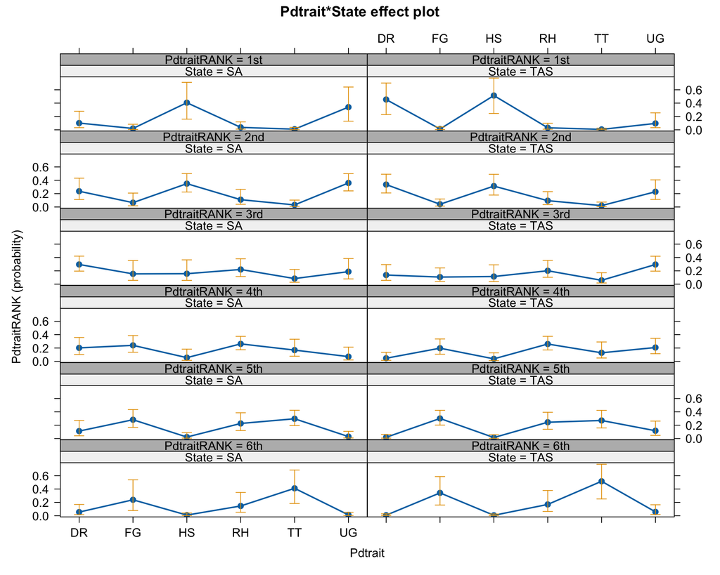

```r
library(effects)
plot(allEffects(fit003))
```

## Dealing with Interaction Term

> The estimates for the interaction term in the model summary are tricky!! Needs a bit of extra work to explain them. To make life easier, because there is enough evidence of a significant “State” and “Pdtrait” interactions (at the 10% level), “State” and “Pdtrait” are bound to form a single categorical variable “State|Pdtrait” with 12 levels. One combination is selected as the reference level.

> We concatenate the variables in the interaction term and refit the model. We go through all the procedures to include p-values, odds ratios, model fit parameters, etc.

### Model #4 (with concateated iteraction term)

```r
#concatenate string/factor variables and store as a new column
df_Pdtrait$stateTrait <- as.factor(paste(df_Pdtrait$State, df_Pdtrait$Pdtrait, sep = "|")) #combining State and Pdtrait
# fit new model
fit004 <- polr(PdtraitRANK ~ stateTrait,
              Hess = TRUE,
              data = df_Pdtrait,
              na.action = na.fail)

# get coefficients (it's in matrix form)
coefficients <- summary(fit004)$coefficients
# calculate p-values
p_value <- (1 - pnorm(abs(coefficients[ ,"t value"]), 0, 1))*2
# bind back to coefficients
coefficients <- cbind(coefficients, p_value)
# calculate odds ratios
odds_ratio <- exp(coefficients[ ,"Value"]) #this is biased for categorical/dummy variables and tends to slightly overstate the effect
# for reduced bias odds ratios for dummy variables, use
odds_ratio_cat <- exp((coefficients[ ,"Value"])-((((coefficients[ ,"Std. Error"])^2)*(coefficients[ ,"Value"]))/2))
# combine with coefficient and p_value
(coefficients <- cbind(
  coefficients[ ,c("Value", "Std. Error", "p_value")],
  odds_ratio, odds_ratio_cat
))
```

```
##                        Value Std. Error      p_value odds_ratio odds_ratio_cat
## stateTraitSA|FG  -1.69724945  0.8716980 5.152740e-02 0.18318670      0.3490935
## stateTraitSA|HS   1.80769394  0.8769071 3.926081e-02 6.09637263      3.0424595
## stateTraitSA|RH  -1.09156695  0.7824231 1.629824e-01 0.33569007      0.4688624
## stateTraitSA|TT  -2.49711872  0.8318438 2.682931e-03 0.08232185      0.1953113
## stateTraitSA|UG   1.52388133  0.8550909 7.472837e-02 4.59000602      2.6294252
## stateTraitTAS|DR  2.00315256  0.7876336 1.098253e-02 7.41238733      3.9820947
## stateTraitTAS|FG -2.20421353  0.7853574 5.006155e-03 0.11033727      0.2177410
## stateTraitTAS|HS  2.24217304  0.8519021 8.489366e-03 9.41376552      4.1726811
## stateTraitTAS|RH -1.26581070  0.7656752 9.829112e-02 0.28201058      0.4087038
## stateTraitTAS|TT -2.92318190  0.8492209 5.770189e-04 0.05376235      0.1542597
## stateTraitTAS|UG -0.05935166  0.7550056 9.373421e-01 0.94237532      0.9584523
## 6th|5th          -2.85775566  0.6441725 9.150949e-06 0.05739744      0.1038476
## 5th|4th          -1.61542325  0.6053207 7.614393e-03 0.19880651      0.2672777
## 4th|3rd          -0.54248084  0.5826510 3.518245e-01 0.58130434      0.6373734
## 3rd|2nd           0.67648787  0.5708371 2.359856e-01 1.96695738      1.7616827
## 2nd|1st           2.18721117  0.6288895 5.053692e-04 8.91032908      5.7816435
```

```r
nobs(fit004)
```

```
## [1] 126
```

```r
logLik(fit004)
```

```
## 'log Lik.' -184.1985 (df=16)
```

```r
DescTools::PseudoR2(fit004, which = "McFadden")
```

```
##  McFadden
## 0.1841021
```

```r
DescTools::PseudoR2(fit004, which = "Nagelkerke")
```

```
## Nagelkerke
##  0.4968111
```

```r
Anova(fit004, type = 3, test.statistic = "Wald")
```

```
## Analysis of Deviance Table (Type III tests)
##
## Response: PdtraitRANK
##            LR Chisq Df Pr(>Chisq)
## stateTrait   83.126 11  3.657e-13 ***
## ---
## Signif. codes:  0 '***' 0.001 '**' 0.01 '*' 0.05 '.' 0.1 ' ' 1
```

> Now the estimates are much easier to comprehend. You can observe that Models #3 and #4 are the same!

> Let’s view the effects plot for Model #4. For POLR, this a plot of the cumulative probabilities with standard errors. NB: `latent = FALSE` computes effects of POLR model as individual-level probabilities and logits. `latent = TRUE` will compute effects of POLR model on the scale of the latent response.

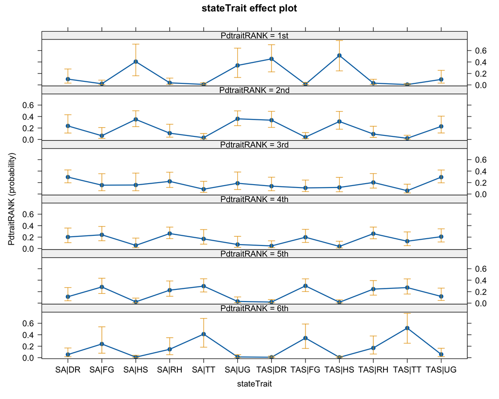

```r
plot(allEffects((fit004), latent = FALSE))
```

> The probability estimates (effects) among the ranks is still the same as for Model #3.

Multiple comparisons of model coefficients

```r
library(emmeans)
#get estimated means coefficients of factor levels for a categorical predictor and store
em <- emmeans(fit004, "stateTrait")
#get multiple comparisons OR contrasts among the factor levels
#contrast(em, "pairwise", adjust = "Tukey")
#save multiple comparisons as a dataframe
df_EstCOMP <- data.frame(contrast(em, "pairwise", adjust = "Tukey"), check.names = FALSE, stringsAsFactors = FALSE)
# calculate odds ratios
df_EstCOMP$OR <- round((exp(df_EstCOMP[ ,"estimate"])-1)*100)
# for reduced bias odds ratios for the differences in parameter estimates, use
df_EstCOMP$OR_cat <- round(((exp((df_EstCOMP[ ,"estimate"])-((((df_EstCOMP[ ,"SE"])^2)*(df_EstCOMP[ ,"estimate"]))/2)))-1)*100)
#reorder such that contrasts significant p-values will be on top
df_EstCOMP_ord <- df_EstCOMP[order(df_EstCOMP$p.value),]
# View the reordered contrasts
head(df_EstCOMP_ord)
```

```
##           contrast  estimate        SE  df   z.ratio      p.value    OR OR_cat
## 55 TAS|DR - TAS|TT  4.926334 0.8737204 Inf  5.638342 1.124144e-06 13687   2003
## 62 TAS|HS - TAS|TT  5.165355 0.9318882 Inf  5.542891 1.944715e-06 17410   1759
## 40  SA|TT - TAS|DR -4.500271 0.8562534 Inf -5.255771 9.567521e-06   -99    -94
## 52 TAS|DR - TAS|FG  4.207366 0.8113582 Inf  5.185584 1.394457e-05  6618   1582
## 42  SA|TT - TAS|HS -4.739292 0.9155755 Inf -5.176298 1.465161e-05   -99    -94
## 57 TAS|FG - TAS|HS -4.446387 0.8736286 Inf -5.089561 2.315648e-05   -99    -94
```

Select specific contrasts of model coefficients from `df_EstCOMP_ord` for comparison

```r
df_EstCOMP_ord[is.element(df_EstCOMP_ord$contrast,
                          c('SA|DR - TAS|HS',
                            'SA|DR - TAS|TT')),]
```

```
##          contrast  estimate        SE  df   z.ratio    p.value   OR OR_cat
## 10 SA|DR - TAS|TT  2.923182 0.8492209 Inf  3.442193 0.02861528 1760    548
## 8  SA|DR - TAS|HS -2.242173 0.8519021 Inf -2.631961 0.26157251  -89    -76
```

Calculating specific, odds ratios and odds for the contrasts NORMAL (run the code as is)

```r
library(dplyr)

#Subset data
df_EstCOMP_select <- df_EstCOMP %>% filter(contrast == "SA|TT - TAS|TT")
# for reduced bias odds ratios for the differences in parameter estimates, use
#OR <- ((exp(abs((df_EstCOMP_select[ ,"estimate"]))-(((df_EstCOMP_select[ ,"SE"])^2)/2)))-1)*100
ORcat <- exp((df_EstCOMP_select$estimate)-((((df_EstCOMP_select$SE)^2)*(df_EstCOMP_select$estimate))/2))

#ORcat <- exp((df_EstCOMP_select$estimate)-(((df_EstCOMP_select$SE)^2)/2))
Odds_cat <- (ORcat-1)*100
ORnorm <- exp(df_EstCOMP_select$estimate)
Odds_norm <- (ORnorm-1)*100

ORcat #bias-reduced odds ratio; not appropriate for small odds ratios
```

```
## [1] 1.328662
```

```r
Odds_cat #bias-reduced odds;
```

```
## [1] 32.86617
```

```r
ORnorm #normal odds ratio; biased for categorical variables
```

```
## [1] 1.531218
```

```r
Odds_norm #normal odds
```

```
## [1] 53.12175
```

Calculating specific odds for reverse differences that do not show above; REVERSE negative to positive (use absolute `abs` to convert negative estimate to positive)

```r
#Subset data
df_EstCOMP_select <- df_EstCOMP %>% filter(contrast == "SA|HS - SA|UG") #reversing to "SA|UG - SA|HS"
# for reduced bias odds ratios for the differences in parameter estimates, use
ORcat <- exp((abs(df_EstCOMP_select$estimate))-((((df_EstCOMP_select$SE)^2)*(abs(df_EstCOMP_select$estimate)))/2))
# the bias-reduced odds; not appropriate for small odds ratios
Odds_cat <- (ORcat-1)*100

#for normal odds ratio
ORnorm <- exp((abs(df_EstCOMP_select$estimate)))
#Normal odds
Odds_norm <- (ORnorm-1)*100

#view the results
ORcat
```

```
## [1] 1.184205
```

```r
Odds_cat
```

```
## [1] 18.42047
```

```r
ORnorm
```

```
## [1] 1.328184
```

```r
Odds_norm
```

```
## [1] 32.8184
```

Calculating specific odds for reverse differences that do not show above REVERSE positive to negative (multiply the estimate by `-1` to negate it)

```r
#Subset data
df_EstCOMP_select <- df_EstCOMP %>% filter(contrast == "TAS|HS - TAS|UG")
#Reverse estimate positive to negative
REVestimate <- (-1)*(df_EstCOMP_select$estimate)
# for reduced bias odds ratios for the differences in parameter estimates, use
ORcat <- exp(REVestimate-((((df_EstCOMP_select$SE)^2)*(REVestimate))/2))

Odds_cat <- (ORcat-1)*100
ORnorm <- exp(REVestimate)
Odds_norm <- (ORnorm-1)*100

#view the results
ORcat
```

```
## [1] 0.2198929
```

```r
Odds_cat
```

```
## [1] -78.01071
```

```r
ORnorm
```

```
## [1] 0.1001061
```

```r
Odds_norm
```

```
## [1] -89.98939
```

## Estimating predicted probabilities

```r
model_best <- fit003
```

> How does the data frame look like at this point?

```r
head(df_Pdtrait)
```

```
##   Years State Pdtrait PdtraitRANK stateTrait
## 1    25   TAS      HS         1st     TAS|HS
## 2    30   TAS      HS         1st     TAS|HS
## 3    32   TAS      HS         1st     TAS|HS
## 4    35   TAS      DR         1st     TAS|DR
## 5    32   TAS      HS         1st     TAS|HS
## 6    35    SA      HS         1st      SA|HS
```

> Let’s select on the columns for the predictions, i.e., the variables used in the model.

```r
# only keep what is used in the analysis
df_PdtraitRANKselect <- dplyr::select(df_Pdtrait, Pdtrait, State, PdtraitRANK)
levels(df_PdtraitRANKselect$PdtraitRANK) # check the levels of PdtraitRANK again
```

```
## [1] "6th" "5th" "4th" "3rd" "2nd" "1st"
```

```r
head(df_PdtraitRANKselect)
```

```
##   Pdtrait State PdtraitRANK
## 1      HS   TAS         1st
## 2      HS   TAS         1st
## 3      HS   TAS         1st
## 4      DR   TAS         1st
## 5      HS   TAS         1st
## 6      HS    SA         1st
```

```r
# add the predicted probabilities to the data frame
df_PdtraitRANKselect <- cbind(df_PdtraitRANKselect, predict(model_best, type = "probs"))

head(df_PdtraitRANKselect) # show the probabilities
```

```
##   Pdtrait State PdtraitRANK         6th        5th        4th       3rd
## 1      HS   TAS         1st 0.006058005 0.01461746 0.03746505 0.1146582
## 2      HS   TAS         1st 0.006058005 0.01461746 0.03746505 0.1146582
## 3      HS   TAS         1st 0.006058005 0.01461746 0.03746505 0.1146582
## 4      DR   TAS         1st 0.007683544 0.01843667 0.04659864 0.1370062
## 5      HS   TAS         1st 0.006058005 0.01461746 0.03746505 0.1146582
## 6      HS    SA         1st 0.009325349 0.02225083 0.05546220 0.1568881
##         2nd       1st
## 1 0.3134187 0.5137825
## 2 0.3134187 0.5137825
## 3 0.3134187 0.5137825
## 4 0.3361934 0.4540815
## 5 0.3134187 0.5137825
## 6 0.3498271 0.4062464
```

> We tidy up the predicted probabilities for plotting.

```r
library(tidyverse)
# convert the data frame to long format for plotting
df_plot <- gather(df_PdtraitRANKselect, key = Predicted, value = Probability, 4:9) #edit column numbers to suit your data frame

head(df_plot) # examine the data
```

```
##   Pdtrait State PdtraitRANK Predicted Probability
## 1      HS   TAS         1st       6th 0.006058005
## 2      HS   TAS         1st       6th 0.006058005
## 3      HS   TAS         1st       6th 0.006058005
## 4      DR   TAS         1st       6th 0.007683544
## 5      HS   TAS         1st       6th 0.006058005
## 6      HS    SA         1st       6th 0.009325349
```

> Remove duplicate rows - rows with repeated probabilities

```r
# only keep the columns we need and remove duplicate rows
df_plot <- df_plot %>% dplyr::select(Pdtrait, State, Predicted, Probability) %>%
  unique()
# ensure Predicted column is ordered
df_plot$Predicted <- ordered(df_plot$Predicted,
  levels = c("6th", "5th", "4th", "3rd", "2nd", "1st"))
# rearrange the rows
df_plot <- df_plot %>%  arrange(Pdtrait, State, Predicted)

df_plot # look at the whole data frame
```

```
##    Pdtrait State Predicted Probability
## 1       DR    SA       6th 0.054270555
## 2       DR    SA       5th 0.111543168
## 3       DR    SA       4th 0.201753053
## 4       DR    SA       3rd 0.295368652
## 5       DR    SA       2nd 0.236156876
## 6       DR    SA       1st 0.100907695
## 7       DR   TAS       6th 0.007683544
## 8       DR   TAS       5th 0.018436675
## 9       DR   TAS       4th 0.046598636
## 10      DR   TAS       3rd 0.137006219
## 11      DR   TAS       2nd 0.336193438
## 12      DR   TAS       1st 0.454081487
## 13      FG    SA       6th 0.238601338
## 14      FG    SA       5th 0.281892180
```

[output cut: 58 more lines]

## Plot stack column chart of predicted probabilities for the model

```r
library(ggplot2)
library(ggthemes)     # provides additional ggplot themes
library(RColorBrewer) # provides additional colors
library(cowplot)      # place multiple ggplots side by side
```

```r
plot_PdtraitsRANK <- ggplot(df_plot, aes(x = State, y = Probability, fill = Predicted)) +
  geom_col(position = position_stack(reverse = TRUE)) +
  scale_y_continuous(breaks = c(0.0,0.2,0.4,0.6,0.8,1.0)) +
  facet_wrap(~ Pdtrait, ncol=6) +
  labs(x = "Australian State", y = "Predicted probability", fill = "Rank")
theme(legend.title = element_text(size=10, face="bold")) +
  theme(legend.text = element_text(size=10))
```

[output not shown]

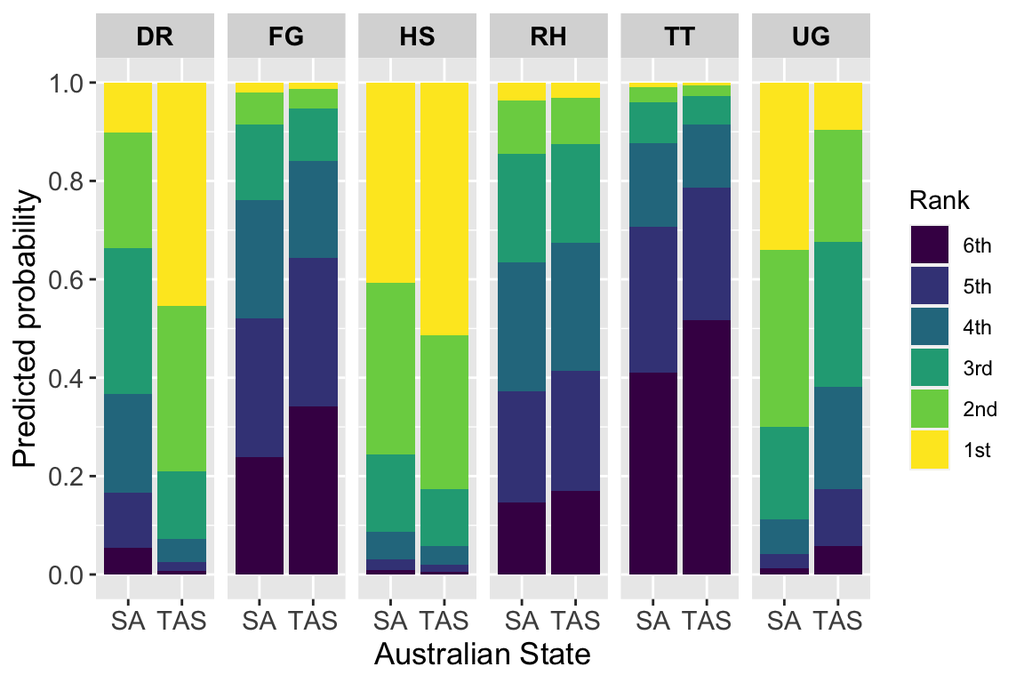

```r
plot_PdtraitsRANKfin <- plot_PdtraitsRANK +
  theme(axis.title.x = element_text(size=13)) +
  theme(axis.title.y = element_text(size=13)) +
  theme(axis.text.x = element_text(size=11)) +
  theme(axis.text.y = element_text(size=11)) +
  theme(strip.text.x = element_text(size = 11, color = "black", face = "bold"))

plot_PdtraitsRANKfin
```

## Predict mean categorical rank outcomes for specific traits of in each state

> Now, instead of cumulative probablities of the ranking levels as demostrated above, we can predict the mean categorical outcomes using the best POLR model. For example we can use the model to generate the mean rank likely to be assigned the production trait, disease resistance by SA producers. Below is a demostration of how to do these predictions for all twelvee combinations of State*Pdtrait interactions.

```r
# Get levels of each categorical predictor using the terms in the model
LEVELS1 <- levels(df_PdtraitRANKselect$Pdtrait)
LEVELS2 <- levels(df_PdtraitRANKselect$State)
```

```r
# Create a data.frame to store the predictions
df_predRANKS <- data.frame(
  Pdtrait   = rep(LEVELS1, length(LEVELS2)),
  State = rep(LEVELS2, each=length(LEVELS1))
)
```

```r
# Add the predictions
df_predRANKS$predRANKS <- predict(model_best, df_predRANKS)

# View the predicted ranks
df_predRANKS
```

```
##    Pdtrait State predRANKS
## 1       DR    SA       3rd
## 2       FG    SA       5th
## 3       HS    SA       1st
## 4       RH    SA       4th
## 5       TT    SA       6th
## 6       UG    SA       2nd
## 7       DR   TAS       1st
## 8       FG   TAS       6th
## 9       HS   TAS       1st
## 10      RH   TAS       4th
## 11      TT   TAS       6th
## 12      UG   TAS       3rd
```

```r
#sort by State and predRANKS in descending order
df_predRANKS$predRANKS <- ordered(df_predRANKS$predRANKS)
df_predRANKS_ord <- df_predRANKS[order(df_predRANKS$State, df_predRANKS$predRANKS, decreasing = TRUE),]
# View the ordered predicted ranks
df_predRANKS_ord
```

```
##    Pdtrait State predRANKS
## 7       DR   TAS       1st
## 9       HS   TAS       1st
## 12      UG   TAS       3rd
## 10      RH   TAS       4th
## 8       FG   TAS       6th
## 11      TT   TAS       6th
## 3       HS    SA       1st
## 6       UG    SA       2nd
## 1       DR    SA       3rd
## 4       RH    SA       4th
## 2       FG    SA       5th
## 5       TT    SA       6th
```

## Testing the Proportionality Assumption

### Brant-Wald Test

```r
brant::brant(fit001)
```

```
## --------------------------------------------
## Test for X2  df  probability
## --------------------------------------------
## Omnibus      54.52   20  0
## PdtraitFG    4.29    4   0.37
## PdtraitHS    10.64   4   0.03
## PdtraitRH    13.22   4   0.01
## PdtraitTT    4.27    4   0.37
## PdtraitUG    5.38    4   0.25
## --------------------------------------------
##
## H0: Parallel Regression Assumption holds
```

```r
brant::brant(fit002)
```

```
## --------------------------------------------
## Test for X2  df  probability
## --------------------------------------------
## Omnibus      54.52   24  0
## PdtraitFG    4.29    4   0.37
## PdtraitHS    10.64   4   0.03
## PdtraitRH    13.22   4   0.01
## PdtraitTT    4.27    4   0.37
## PdtraitUG    5.38    4   0.25
## StateTAS 0   4   1
## --------------------------------------------
##
## H0: Parallel Regression Assumption holds
```

### Graphical Method [Manually Checking the proportional odds assumption (see detailed explanations at https://stats.oarc.ucla.edu/r/dae/ordinal-logistic-regression/)]

```r
library(Hmisc)

sf <- function(y) {
  c('Y>=1' = qlogis(mean(y >= 1)),
    'Y>=2' = qlogis(mean(y >= 2)),
    'Y>=3' = qlogis(mean(y >= 3)),
    'Y>=4' = qlogis(mean(y >= 4)),
    'Y>=5' = qlogis(mean(y >= 5)),
    'Y>=6' = qlogis(mean(y >= 6)))
}

(s <- with(df_Pdtrait, summary(as.numeric(PdtraitRANK) ~ Pdtrait + State, fun=sf)))
```

```
## as.numeric(PdtraitRANK)      N= 126
##
## +-------+---+---+----+----------+----------+----------+----------+-----------+
## |       |   |  N|Y>=1|      Y>=2|      Y>=3|      Y>=4|      Y>=5|       Y>=6|
## +-------+---+---+----+----------+----------+----------+----------+-----------+
## |Pdtrait| DR| 21| Inf|       Inf| 1.7917595| 1.7917595| 0.6931472|-1.44691898|
## |       | FG| 21| Inf|0.91629073|-0.6931472|-1.1631508|-2.2512918|-2.99573227|
## |       | HS| 21| Inf|       Inf| 2.9957323| 1.1631508| 1.1631508| 0.09531018|
## |       | RH| 21| Inf|1.79175947| 0.9162907|-0.9162907|-2.9957323|       -Inf|
## |       | TT| 21| Inf|0.09531018|-0.9162907|-2.2512918|      -Inf|       -Inf|
## |       | UG| 21| Inf|2.25129180| 1.7917595| 1.1631508|-0.2876821|-1.16315081|
## +-------+---+---+----+----------+----------+----------+----------+-----------+
## |  State| SA| 60| Inf|1.60943791| 0.6931472| 0.0000000|-0.6931472|-1.60943791|
## |       |TAS| 66| Inf|1.60943791| 0.6931472| 0.0000000|-0.6931472|-1.60943791|
## +-------+---+---+----+----------+----------+----------+----------+-----------+
## |Overall|   |126| Inf|1.60943791| 0.6931472| 0.0000000|-0.6931472|-1.60943791|
## +-------+---+---+----+----------+----------+----------+----------+-----------+
```

```r
levels(df_Pdtrait$PdtraitRANK)
```

```
## [1] "6th" "5th" "4th" "3rd" "2nd" "1st"
```

```r
levels(df_Pdtrait$State)
```

```
## [1] "SA"  "TAS"
```

```r
summary(glm(I(as.numeric(PdtraitRANK) >= 2) ~ Pdtrait, family="binomial", data = df_Pdtrait))
```

```
##
## Call:
## glm(formula = I(as.numeric(PdtraitRANK) >= 2) ~ Pdtrait, family = "binomial",
##     data = df_Pdtrait)
##
## Coefficients:
##               Estimate Std. Error z value Pr(>|z|)
## (Intercept)  1.957e+01  2.347e+03   0.008    0.993
## PdtraitFG   -1.865e+01  2.347e+03  -0.008    0.994
## PdtraitHS    5.965e-09  3.319e+03   0.000    1.000
## PdtraitRH   -1.777e+01  2.347e+03  -0.008    0.994
## PdtraitTT   -1.947e+01  2.347e+03  -0.008    0.993
## PdtraitUG   -1.731e+01  2.347e+03  -0.007    0.994
##
## (Dispersion parameter for binomial family taken to be 1)
##
##     Null deviance: 113.541  on 125  degrees of freedom
## Residual deviance:  84.625  on 120  degrees of freedom
## AIC: 96.625
##
## Number of Fisher Scoring iterations: 18
```

```r
summary(glm(I(as.numeric(PdtraitRANK) >= 3) ~ Pdtrait, family="binomial", data = df_Pdtrait))
```

```
##
## Call:
## glm(formula = I(as.numeric(PdtraitRANK) >= 3) ~ Pdtrait, family = "binomial",
##     data = df_Pdtrait)
##
## Coefficients:
##               Estimate Std. Error z value Pr(>|z|)
## (Intercept)  1.792e+00  6.236e-01   2.873 0.004063 **
## PdtraitFG   -2.485e+00  7.766e-01  -3.200 0.001376 **
## PdtraitHS    1.204e+00  1.199e+00   1.004 0.315497
## PdtraitRH   -8.755e-01  7.888e-01  -1.110 0.267060
## PdtraitTT   -2.708e+00  7.888e-01  -3.433 0.000597 ***
## PdtraitUG   -8.323e-16  8.819e-01   0.000 1.000000
## ---
## Signif. codes:  0 '***' 0.001 '**' 0.01 '*' 0.05 '.' 0.1 ' ' 1
##
## (Dispersion parameter for binomial family taken to be 1)
##
##     Null deviance: 160.40  on 125  degrees of freedom
## Residual deviance: 119.48  on 120  degrees of freedom
## AIC: 131.48
##
## Number of Fisher Scoring iterations: 5
```

```r
summary(glm(I(as.numeric(PdtraitRANK) >= 4) ~ Pdtrait, family="binomial", data = df_Pdtrait))
```

```
##
## Call:
## glm(formula = I(as.numeric(PdtraitRANK) >= 4) ~ Pdtrait, family = "binomial",
##     data = df_Pdtrait)
##
## Coefficients:
##             Estimate Std. Error z value Pr(>|z|)
## (Intercept)   1.7918     0.6236   2.873 0.004063 **
## PdtraitFG    -2.9549     0.8071  -3.661 0.000251 ***
## PdtraitHS    -0.6286     0.8071  -0.779 0.436061
## PdtraitRH    -2.7081     0.7888  -3.433 0.000597 ***
## PdtraitTT    -4.0431     0.9702  -4.167 3.09e-05 ***
## PdtraitUG    -0.6286     0.8071  -0.779 0.436061
## ---
## Signif. codes:  0 '***' 0.001 '**' 0.01 '*' 0.05 '.' 0.1 ' ' 1
##
## (Dispersion parameter for binomial family taken to be 1)
##
##     Null deviance: 174.67  on 125  degrees of freedom
## Residual deviance: 124.72  on 120  degrees of freedom
## AIC: 136.72
##
## Number of Fisher Scoring iterations: 4
```

```r
summary(glm(I(as.numeric(PdtraitRANK) >= 5) ~ Pdtrait, family="binomial", data = df_Pdtrait))
```

```
##
## Call:
## glm(formula = I(as.numeric(PdtraitRANK) >= 5) ~ Pdtrait, family = "binomial",
##     data = df_Pdtrait)
##
## Coefficients:
##              Estimate Std. Error z value Pr(>|z|)
## (Intercept)    0.6931     0.4629   1.497 0.134297
## PdtraitFG     -2.9444     0.8757  -3.362 0.000773 ***
## PdtraitHS      0.4700     0.6905   0.681 0.496077
## PdtraitRH     -3.6889     1.1244  -3.281 0.001035 **
## PdtraitTT    -19.2592  1423.3565  -0.014 0.989204
## PdtraitUG     -0.9808     0.6393  -1.534 0.124986
## ---
## Signif. codes:  0 '***' 0.001 '**' 0.01 '*' 0.05 '.' 0.1 ' ' 1
##
## (Dispersion parameter for binomial family taken to be 1)
##
##     Null deviance: 160.402  on 125  degrees of freedom
## Residual deviance:  99.718  on 120  degrees of freedom
## AIC: 111.72
##
## Number of Fisher Scoring iterations: 17
```

```r
summary(glm(I(as.numeric(PdtraitRANK) >= 6) ~ Pdtrait, family="binomial", data = df_Pdtrait))
```

```
##
## Call:
## glm(formula = I(as.numeric(PdtraitRANK) >= 6) ~ Pdtrait, family = "binomial",
##     data = df_Pdtrait)
##
## Coefficients:
##              Estimate Std. Error z value Pr(>|z|)
## (Intercept)   -1.4469     0.5557  -2.604  0.00922 **
## PdtraitFG     -1.5488     1.1657  -1.329  0.18396
## PdtraitHS      1.5422     0.7069   2.182  0.02914 *
## PdtraitRH    -18.1191  2346.7181  -0.008  0.99384
## PdtraitTT    -18.1191  2346.7181  -0.008  0.99384
## PdtraitUG      0.2838     0.7559   0.375  0.70734
## ---
## Signif. codes:  0 '***' 0.001 '**' 0.01 '*' 0.05 '.' 0.1 ' ' 1
##
## (Dispersion parameter for binomial family taken to be 1)
##
##     Null deviance: 113.541  on 125  degrees of freedom
## Residual deviance:  80.608  on 120  degrees of freedom
## AIC: 92.608
##
## Number of Fisher Scoring iterations: 18
```

```r
s[, 5] <- s[, 5] - s[, 4]
s[, 4] <- s[, 4] - s[, 4]

s # print
```

```
## as.numeric(PdtraitRANK)      N= 126
##
## +-------+---+---+----+----------+----+----------+----------+-----------+
## |       |   |  N|Y>=1|      Y>=2|Y>=3|      Y>=4|      Y>=5|       Y>=6|
## +-------+---+---+----+----------+----+----------+----------+-----------+
## |Pdtrait| DR| 21| Inf|       Inf|   0| 0.0000000| 0.6931472|-1.44691898|
## |       | FG| 21| Inf|0.91629073|   0|-0.4700036|-2.2512918|-2.99573227|
## |       | HS| 21| Inf|       Inf|   0|-1.8325815| 1.1631508| 0.09531018|
## |       | RH| 21| Inf|1.79175947|   0|-1.8325815|-2.9957323|       -Inf|
## |       | TT| 21| Inf|0.09531018|   0|-1.3350011|      -Inf|       -Inf|
## |       | UG| 21| Inf|2.25129180|   0|-0.6286087|-0.2876821|-1.16315081|
## +-------+---+---+----+----------+----+----------+----------+-----------+
## |  State| SA| 60| Inf|1.60943791|   0|-0.6931472|-0.6931472|-1.60943791|
## |       |TAS| 66| Inf|1.60943791|   0|-0.6931472|-0.6931472|-1.60943791|
## +-------+---+---+----+----------+----+----------+----------+-----------+
## |Overall|   |126| Inf|1.60943791|   0|-0.6931472|-0.6931472|-1.60943791|
## +-------+---+---+----+----------+----+----------+----------+-----------+
```

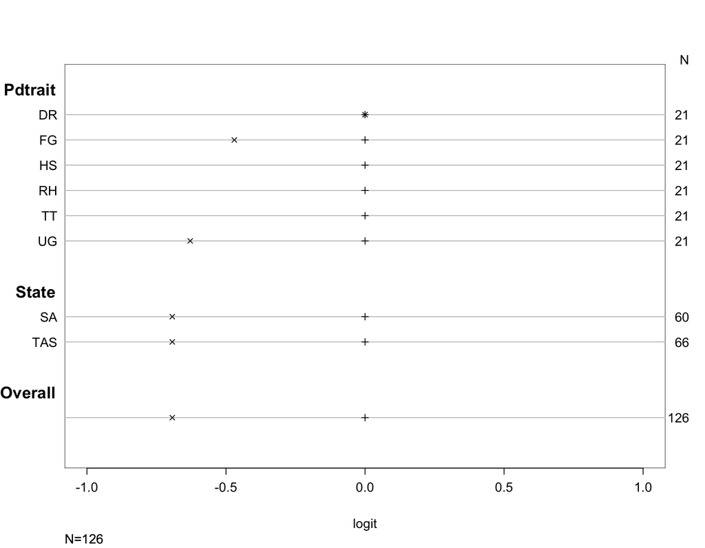

```r
plot(s, which=3:4, pch=3:4, xlab='logit', main=' ', xlim=range(s[,4:4]))
```